# Compound channel hydraulic flume with two longitudinal friction

Felipe

2025-08-19

# Estimation: constant in the main channel and constant in the floodplain but separated in two parts.

# Experimental set up

A compound channel setup was used for this case study. The paper including all information about the experience was found in [Dupuis et al. (2017)](https://doi.org/10.1007/s10652-017-9525-0).

- Length: 18 m
- Width: 3 m
- Slope: 0.00105
- Main channel: 1 m wide rectangular glass bed
- Floodplain: two 1 m wide rectangular configuration. Both floodplains were covered either by plastic grass alone (meadow) or by an array of emergent cylinders set on the plastic grass (wood).
- Vertical distance from the main channel to the floodplain: 0.115 m
- Flow conditions: uniform flow with a total discharge of 162 L/s, varying the discharge in the floodplain of 12 and 18 L/s.
- Water level measurements: the measures were taken spatial distributed from 2 m to 17 m.

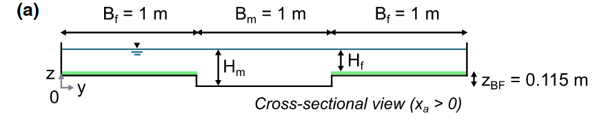

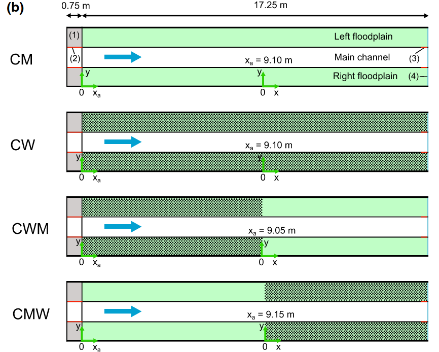

# Objectives and remarks of the case study

- Assess the methodology to get a estimation of a piecewise function for the friction coefficient giving the separation manually.

# Calibration data

The selected case was a transition from wood to grass. WSE measurements were taken in the main channel and the floodplain at different positions. To compare with the simulations, a single value of WSE was calculated for each position by averaging the WSE values. Then the standard devaition was estimated using all the values for estimating a regression with `lm` function.

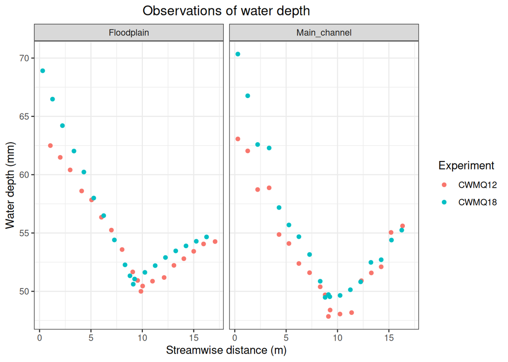

| event | reach | x | t | WSE | Discharge | Velocity | Y_Kmin | Y_Kmoy | Yu_z | Yu_Q | Yu_V | Yu_Kmin | Yu_Kmoy |
| --- | --- | --- | --- | --- | --- | --- | --- | --- | --- | --- | --- | --- | --- |
| 1 | 1 | 2.225 | 3420 | 0.1949608 | -9999 | -9999 | -9999 | -9999 | 0.0222257 | -9999 | -9999 | -9999 | -9999 |
| 1 | 1 | 4.310 | 3420 | 0.1880788 | -9999 | -9999 | -9999 | -9999 | 0.0222257 | -9999 | -9999 | -9999 | -9999 |
| 1 | 1 | 5.270 | 3420 | 0.1852095 | -9999 | -9999 | -9999 | -9999 | 0.0222257 | -9999 | -9999 | -9999 | -9999 |
| 1 | 1 | 6.240 | 3420 | 0.1829345 | -9999 | -9999 | -9999 | -9999 | 0.0222257 | -9999 | -9999 | -9999 | -9999 |
| 1 | 1 | 8.315 | 3420 | 0.1767361 | -9999 | -9999 | -9999 | -9999 | 0.0222257 | -9999 | -9999 | -9999 | -9999 |
| 1 | 1 | 9.115 | 3420 | 0.1744950 | -9999 | -9999 | -9999 | -9999 | 0.0222257 | -9999 | -9999 | -9999 | -9999 |
| 1 | 1 | 9.250 | 3420 | 0.1744835 | -9999 | -9999 | -9999 | -9999 | 0.0222257 | -9999 | -9999 | -9999 | -9999 |
| 1 | 1 | 10.250 | 3420 | 0.1737731 | -9999 | -9999 | -9999 | -9999 | 0.0222257 | -9999 | -9999 | -9999 | -9999 |
| 1 | 1 | 11.250 | 3420 | 0.1732561 | -9999 | -9999 | -9999 | -9999 | 0.0222257 | -9999 | -9999 | -9999 | -9999 |
| 1 | 1 | 12.250 | 3420 | 0.1728932 | -9999 | -9999 | -9999 | -9999 | 0.0222257 | -9999 | -9999 | -9999 | -9999 |
| 1 | 1 | 13.250 | 3420 | 0.1729610 | -9999 | -9999 | -9999 | -9999 | 0.0222257 | -9999 | -9999 | -9999 | -9999 |
| 2 | 1 | 2.225 | 3420 | 0.1902885 | -9999 | -9999 | -9999 | -9999 | 0.0222257 | -9999 | -9999 | -9999 | -9999 |
| 2 | 1 | 2.975 | 3420 | 0.1911852 | -9999 | -9999 | -9999 | -9999 | 0.0222257 | -9999 | -9999 | -9999 | -9999 |
| 2 | 1 | 3.345 | 3420 | 0.1892610 | -9999 | -9999 | -9999 | -9999 | 0.0222257 | -9999 | -9999 | -9999 | -9999 |
| 2 | 1 | 4.095 | 3420 | 0.1882043 | -9999 | -9999 | -9999 | -9999 | 0.0222257 | -9999 | -9999 | -9999 | -9999 |
| 2 | 1 | 5.060 | 3420 | 0.1864261 | -9999 | -9999 | -9999 | -9999 | 0.0222257 | -9999 | -9999 | -9999 | -9999 |
| 2 | 1 | 6.240 | 3420 | 0.1797323 | -9999 | -9999 | -9999 | -9999 | 0.0222257 | -9999 | -9999 | -9999 | -9999 |
| 2 | 1 | 6.990 | 3420 | 0.1818093 | -9999 | -9999 | -9999 | -9999 | 0.0222257 | -9999 | -9999 | -9999 | -9999 |
| 2 | 1 | 8.030 | 3420 | 0.1790497 | -9999 | -9999 | -9999 | -9999 | 0.0222257 | -9999 | -9999 | -9999 | -9999 |
| 2 | 1 | 8.795 | 3420 | 0.1743624 | -9999 | -9999 | -9999 | -9999 | 0.0222257 | -9999 | -9999 | -9999 | -9999 |
| 2 | 1 | 9.065 | 3420 | 0.1760431 | -9999 | -9999 | -9999 | -9999 | 0.0222257 | -9999 | -9999 | -9999 | -9999 |
| 2 | 1 | 9.115 | 3420 | 0.1721755 | -9999 | -9999 | -9999 | -9999 | 0.0222257 | -9999 | -9999 | -9999 | -9999 |
| 2 | 1 | 9.545 | 3420 | 0.1748087 | -9999 | -9999 | -9999 | -9999 | 0.0222257 | -9999 | -9999 | -9999 | -9999 |
| 2 | 1 | 10.030 | 3420 | 0.1738211 | -9999 | -9999 | -9999 | -9999 | 0.0222257 | -9999 | -9999 | -9999 | -9999 |
| 2 | 1 | 11.370 | 3420 | 0.1701349 | -9999 | -9999 | -9999 | -9999 | 0.0222257 | -9999 | -9999 | -9999 | -9999 |
| 2 | 1 | 12.120 | 3420 | 0.1723571 | -9999 | -9999 | -9999 | -9999 | 0.0222257 | -9999 | -9999 | -9999 | -9999 |
| 2 | 1 | 12.325 | 3420 | 0.1718688 | -9999 | -9999 | -9999 | -9999 | 0.0222257 | -9999 | -9999 | -9999 | -9999 |
| 2 | 1 | 13.290 | 3420 | 0.1715232 | -9999 | -9999 | -9999 | -9999 | 0.0222257 | -9999 | -9999 | -9999 | -9999 |

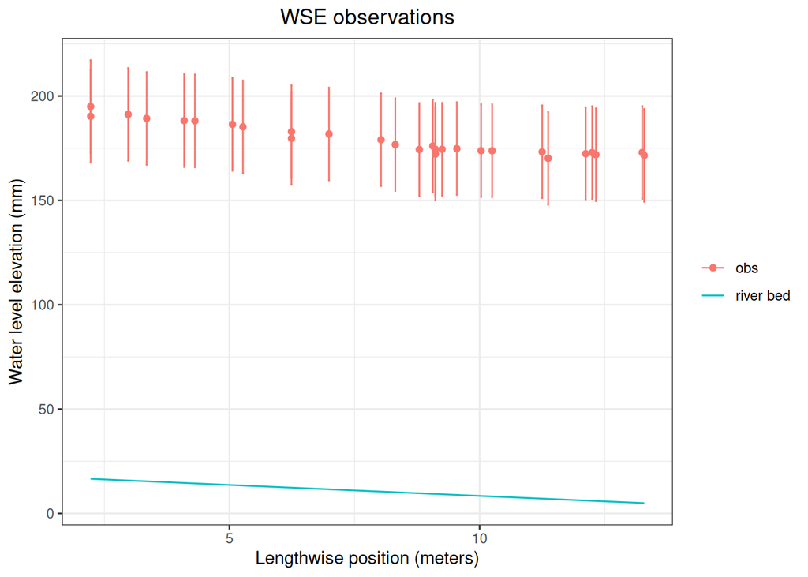

# Estimation with a standard deviation of 22 mm for WSE observations

## Check MCMC

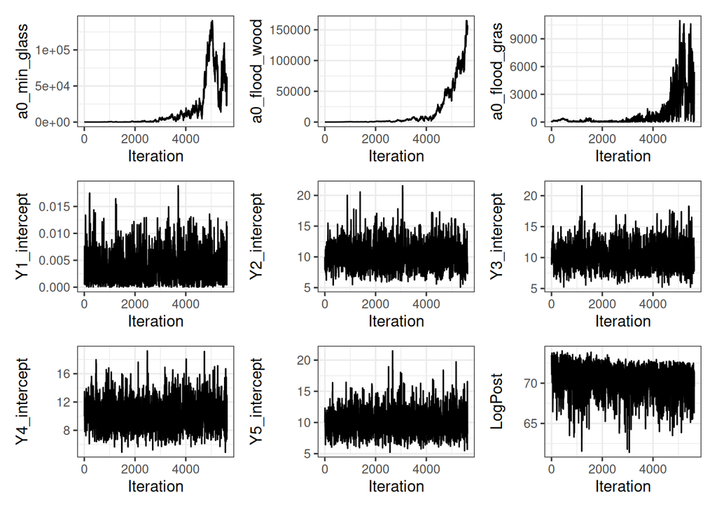

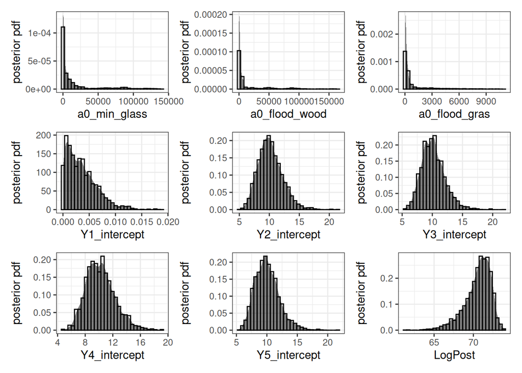

### Partial conclusions:

Instabilities have been detected. No explanation has been found for this problem.

## Check summary

Zoom into the MAP and standard deviation of the error model: WSE in mm, discharge in L/s and velocity in mm/s.

|  | a0_min_glass | a0_flood_wood | a0_flood_grass | Y1_intercept | Y2_intercept | Y3_intercept | Y4_intercept | Y5_intercept |
| --- | --- | --- | --- | --- | --- | --- | --- | --- |
| N | 5.62600e+03 | 5.62600e+03 | 5.62600e+03 | 5.62600e+03 | 5626.000000 | 5626.000000 | 5626.000000 | 5626.000000 |
| Minimum | 3.78440e+01 | 1.41694e+01 | 3.32429e-01 | 3.00000e-07 | 5.072160 | 5.211930 | 4.885210 | 5.215800 |
| Maximum | 1.40569e+05 | 1.64928e+05 | 1.09640e+04 | 1.88446e-02 | 21.565100 | 21.604900 | 19.221700 | 21.474600 |
| Range | 1.40531e+05 | 1.64914e+05 | 1.09637e+04 | 1.88443e-02 | 16.492900 | 16.393000 | 14.336500 | 16.258800 |
| Mean | 1.55734e+04 | 1.57727e+04 | 8.89994e+02 | 3.56030e-03 | 10.197200 | 10.152900 | 10.232200 | 10.050100 |
| Median | 1.48532e+03 | 1.61024e+03 | 1.82104e+02 | 2.99400e-03 | 10.012300 | 10.016600 | 10.070400 | 9.880150 |
| Q10% | 6.67302e+01 | 1.13450e+02 | 3.84303e+01 | 4.51800e-04 | 7.730810 | 7.841140 | 7.698550 | 7.686330 |
| Q25% | 1.79057e+02 | 3.72265e+02 | 6.90156e+01 | 1.24670e-03 | 8.785770 | 8.810230 | 8.705910 | 8.595480 |
| Q75% | 1.29831e+04 | 8.22131e+03 | 5.62354e+02 | 5.18440e-03 | 11.433800 | 11.313800 | 11.483100 | 11.256500 |
| Q90% | 6.42310e+04 | 5.89468e+04 | 2.96937e+03 | 7.43530e-03 | 12.908500 | 12.666600 | 12.985200 | 12.579600 |
| St.Dev. | 2.92912e+04 | 3.09470e+04 | 1.78679e+03 | 2.88930e-03 | 2.054510 | 1.945910 | 2.113690 | 1.998370 |
| Variance | 8.57977e+08 | 9.57718e+08 | 3.19261e+06 | 8.30000e-06 | 4.220990 | 3.786550 | 4.467690 | 3.993500 |
| CV | 1.88085e+00 | 1.96206e+00 | 2.00764e+00 | 8.11532e-01 | 0.201477 | 0.191660 | 0.206573 | 0.198841 |
| Skewness | 2.31314e+00 | 2.45332e+00 | 2.99184e+00 | 1.16752e+00 | 0.683906 | 0.718317 | 0.566918 | 0.745031 |
| Kurtosis | 4.46775e+00 | 5.65191e+00 | 9.11416e+00 | 1.67336e+00 | 1.095530 | 1.269380 | 0.457451 | 1.197610 |
| MaxPost | 6.63714e+01 | 6.02276e+01 | 3.57331e+02 | 1.22000e-03 | 10.283100 | 10.477600 | 8.785440 | 10.343600 |

|  | a0_min_glass | a0_flood_wood | a0_flood_grass | Y1_intercept | Y2_intercept | Y3_intercept | Y4_intercept | Y5_intercept |
| --- | --- | --- | --- | --- | --- | --- | --- | --- |
| St.Dev. | 29291.2000 | 30947.0000 | 1786.790 | 2.88930 | 2054.51 | 194.591 | 2.11369 | 1.99837 |
| MaxPost | 66.3714 | 60.2276 | 357.331 | 1.21999 | 10283.10 | 1047.760 | 8.78544 | 10.34360 |

## Check spatial friction distribution

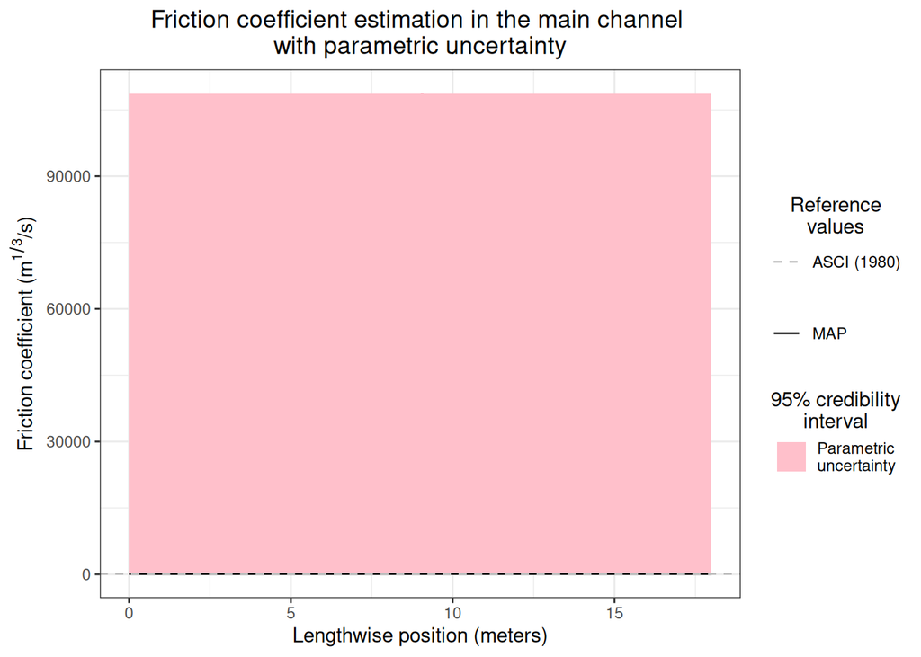

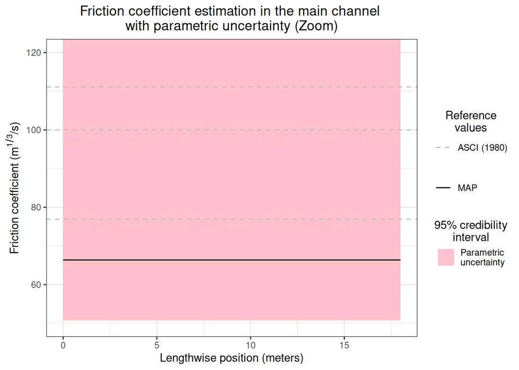

The MAP estimation is lower than the literature values to the glass friction coefficient.

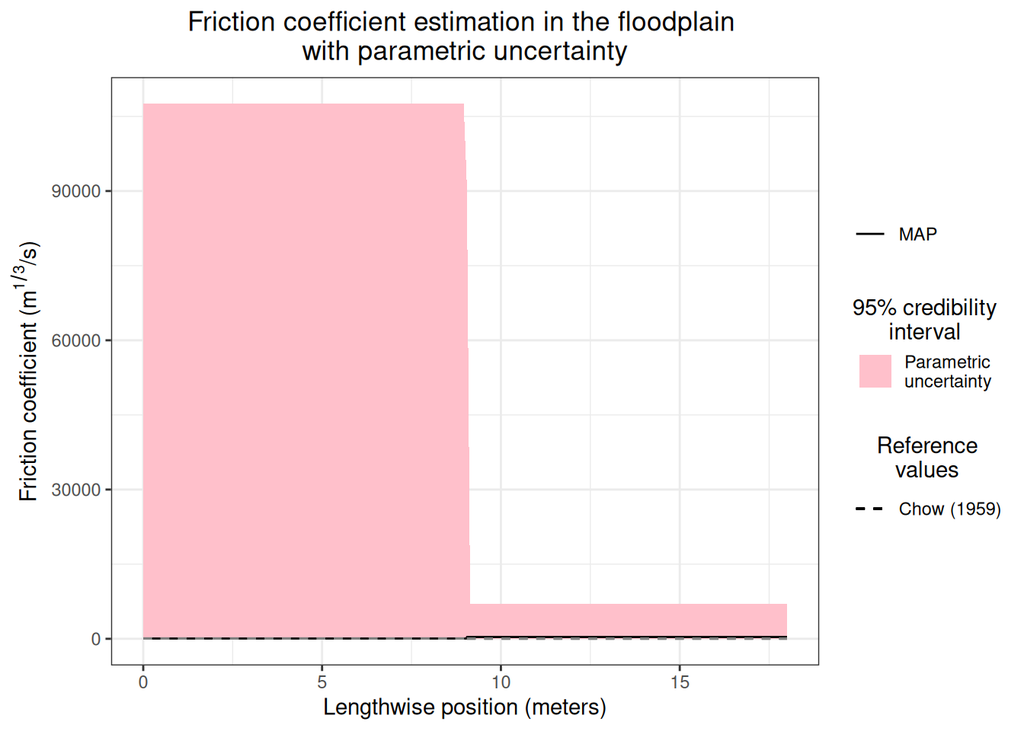

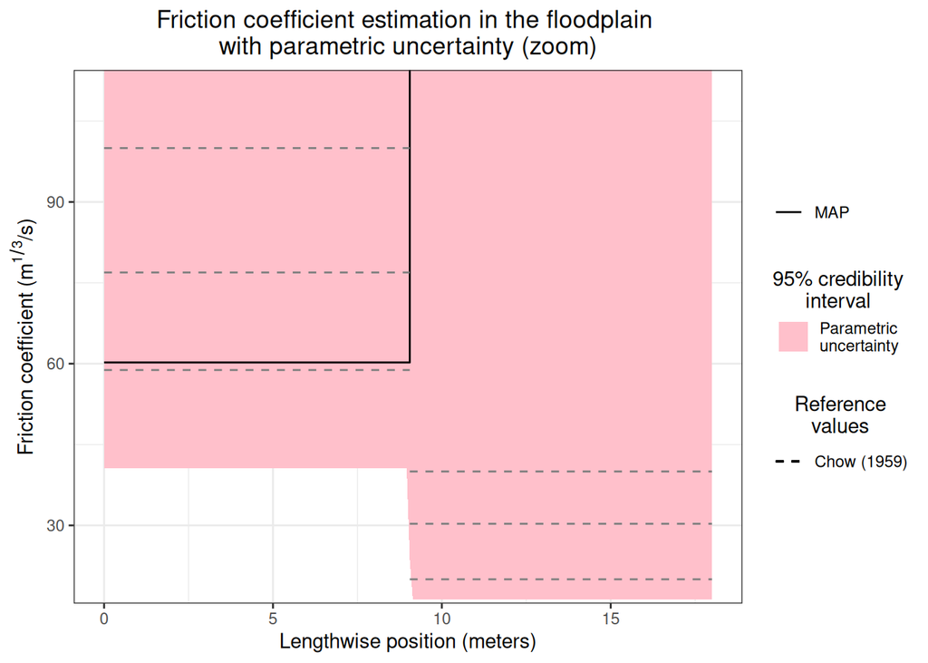

### Partial conclusions:

The first part of the floodplain (wood) is estimated between the literature values. However, the second part of the floodplain (grass) is not coherent to the literature values, increasing instead of decreasing as expected.

## Check of residuals

| event | reach | x | t | WSE | Discharge | Velocity | Y_Kmin | Y_Kmoy | Yu_z | Yu_Q | Yu_V | Yu_Kmin | Yu_Kmoy |
| --- | --- | --- | --- | --- | --- | --- | --- | --- | --- | --- | --- | --- | --- |
| 1 | 1 | 2.225 | 3420 | 0.1949608 | -9999 | -9999 | -9999 | -9999 | 0.0222257 | -9999 | -9999 | -9999 | -9999 |
| 1 | 1 | 4.310 | 3420 | 0.1880788 | -9999 | -9999 | -9999 | -9999 | 0.0222257 | -9999 | -9999 | -9999 | -9999 |
| 1 | 1 | 5.270 | 3420 | 0.1852095 | -9999 | -9999 | -9999 | -9999 | 0.0222257 | -9999 | -9999 | -9999 | -9999 |
| 1 | 1 | 6.240 | 3420 | 0.1829345 | -9999 | -9999 | -9999 | -9999 | 0.0222257 | -9999 | -9999 | -9999 | -9999 |
| 1 | 1 | 8.315 | 3420 | 0.1767361 | -9999 | -9999 | -9999 | -9999 | 0.0222257 | -9999 | -9999 | -9999 | -9999 |
| 1 | 1 | 9.115 | 3420 | 0.1744950 | -9999 | -9999 | -9999 | -9999 | 0.0222257 | -9999 | -9999 | -9999 | -9999 |
| 1 | 1 | 9.250 | 3420 | 0.1744835 | -9999 | -9999 | -9999 | -9999 | 0.0222257 | -9999 | -9999 | -9999 | -9999 |
| 1 | 1 | 10.250 | 3420 | 0.1737731 | -9999 | -9999 | -9999 | -9999 | 0.0222257 | -9999 | -9999 | -9999 | -9999 |
| 1 | 1 | 11.250 | 3420 | 0.1732561 | -9999 | -9999 | -9999 | -9999 | 0.0222257 | -9999 | -9999 | -9999 | -9999 |
| 1 | 1 | 12.250 | 3420 | 0.1728932 | -9999 | -9999 | -9999 | -9999 | 0.0222257 | -9999 | -9999 | -9999 | -9999 |
| 1 | 1 | 13.250 | 3420 | 0.1729610 | -9999 | -9999 | -9999 | -9999 | 0.0222257 | -9999 | -9999 | -9999 | -9999 |
| 2 | 1 | 2.225 | 3420 | 0.1902885 | -9999 | -9999 | -9999 | -9999 | 0.0222257 | -9999 | -9999 | -9999 | -9999 |
| 2 | 1 | 2.975 | 3420 | 0.1911852 | -9999 | -9999 | -9999 | -9999 | 0.0222257 | -9999 | -9999 | -9999 | -9999 |
| 2 | 1 | 3.345 | 3420 | 0.1892610 | -9999 | -9999 | -9999 | -9999 | 0.0222257 | -9999 | -9999 | -9999 | -9999 |
| 2 | 1 | 4.095 | 3420 | 0.1882043 | -9999 | -9999 | -9999 | -9999 | 0.0222257 | -9999 | -9999 | -9999 | -9999 |
| 2 | 1 | 5.060 | 3420 | 0.1864261 | -9999 | -9999 | -9999 | -9999 | 0.0222257 | -9999 | -9999 | -9999 | -9999 |
| 2 | 1 | 6.240 | 3420 | 0.1797323 | -9999 | -9999 | -9999 | -9999 | 0.0222257 | -9999 | -9999 | -9999 | -9999 |
| 2 | 1 | 6.990 | 3420 | 0.1818093 | -9999 | -9999 | -9999 | -9999 | 0.0222257 | -9999 | -9999 | -9999 | -9999 |
| 2 | 1 | 8.030 | 3420 | 0.1790497 | -9999 | -9999 | -9999 | -9999 | 0.0222257 | -9999 | -9999 | -9999 | -9999 |
| 2 | 1 | 8.795 | 3420 | 0.1743624 | -9999 | -9999 | -9999 | -9999 | 0.0222257 | -9999 | -9999 | -9999 | -9999 |
| 2 | 1 | 9.065 | 3420 | 0.1760431 | -9999 | -9999 | -9999 | -9999 | 0.0222257 | -9999 | -9999 | -9999 | -9999 |
| 2 | 1 | 9.115 | 3420 | 0.1721755 | -9999 | -9999 | -9999 | -9999 | 0.0222257 | -9999 | -9999 | -9999 | -9999 |
| 2 | 1 | 9.545 | 3420 | 0.1748087 | -9999 | -9999 | -9999 | -9999 | 0.0222257 | -9999 | -9999 | -9999 | -9999 |
| 2 | 1 | 10.030 | 3420 | 0.1738211 | -9999 | -9999 | -9999 | -9999 | 0.0222257 | -9999 | -9999 | -9999 | -9999 |
| 2 | 1 | 11.370 | 3420 | 0.1701349 | -9999 | -9999 | -9999 | -9999 | 0.0222257 | -9999 | -9999 | -9999 | -9999 |
| 2 | 1 | 12.120 | 3420 | 0.1723571 | -9999 | -9999 | -9999 | -9999 | 0.0222257 | -9999 | -9999 | -9999 | -9999 |
| 2 | 1 | 12.325 | 3420 | 0.1718688 | -9999 | -9999 | -9999 | -9999 | 0.0222257 | -9999 | -9999 | -9999 | -9999 |
| 2 | 1 | 13.290 | 3420 | 0.1715232 | -9999 | -9999 | -9999 | -9999 | 0.0222257 | -9999 | -9999 | -9999 | -9999 |

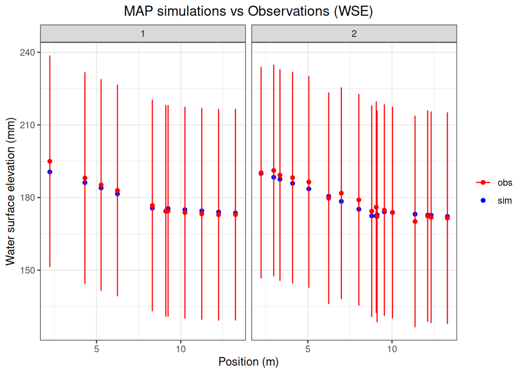

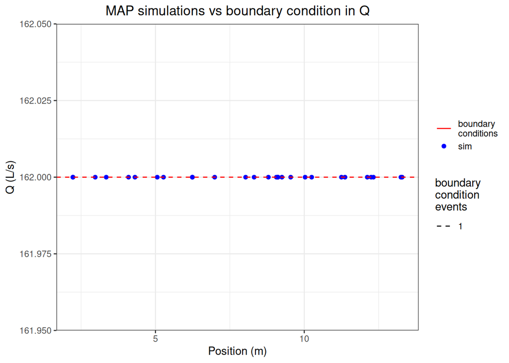

# Estimation with the same uncertainty for WSE observations but introducing a pseudo-observation for the friction coefficient in the main channel

## Check MCMC

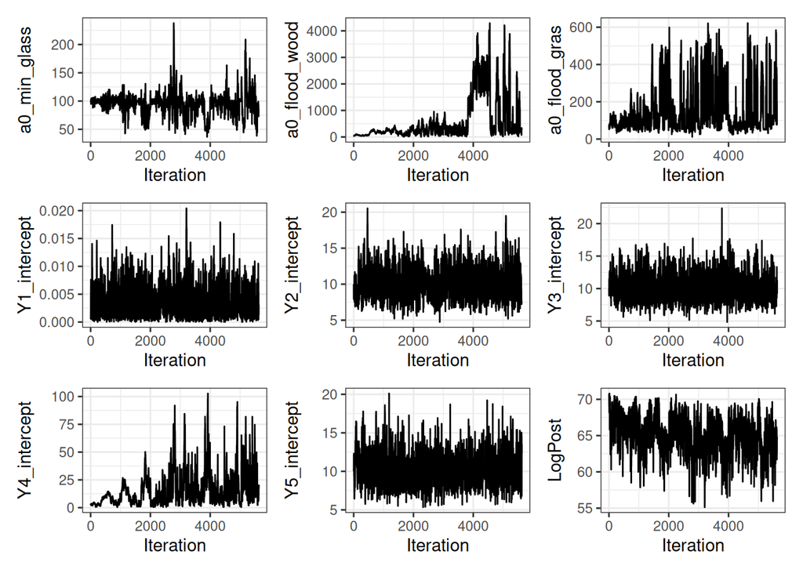

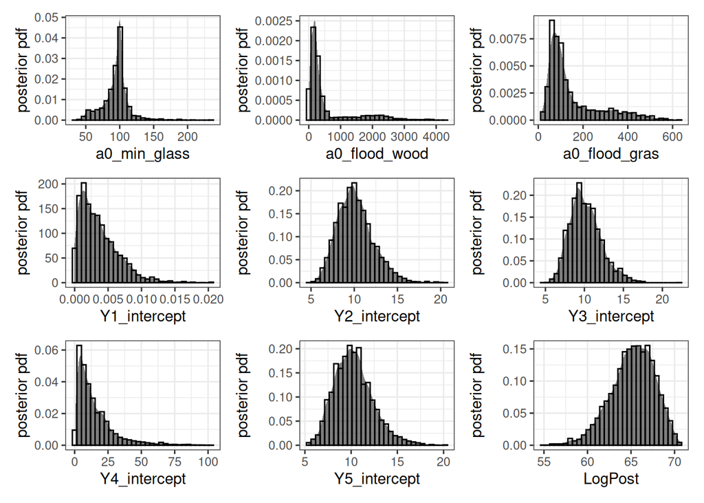

Pseudo-observations force the estimation of the frictio in the main channel closer to observations. However, instabilites have been detected for the floodplain friction coefficients.

## Check summary

Zoom into the MAP and standard deviation of the error model: WSE in mm, discharge in L/s and velocity in mm/s.

|  | a0_min_glass | a0_flood_wood | a0_flood_grass | Y1_intercept | Y2_intercept | Y3_intercept | Y4_intercept | Y5_intercept |
| --- | --- | --- | --- | --- | --- | --- | --- | --- |
| N | 5626.000000 | 5.62600e+03 | 5.62600e+03 | 5.62600e+03 | 5626.000000 | 5626.000000 | 5626.000000 | 5626.000000 |
| Minimum | 36.684600 | 5.15705e+00 | 1.17890e+01 | 4.00000e-07 | 4.743750 | 4.843950 | 0.397386 | 5.339790 |
| Maximum | 237.884000 | 4.29089e+03 | 6.21795e+02 | 2.04196e-02 | 20.535100 | 22.354200 | 102.719000 | 20.106600 |
| Range | 201.199000 | 4.28573e+03 | 6.10006e+02 | 2.04192e-02 | 15.791300 | 17.510200 | 102.322000 | 14.766800 |
| Mean | 94.642600 | 5.69488e+02 | 1.51346e+02 | 3.65150e-03 | 10.133100 | 10.165600 | 14.949600 | 10.284900 |
| Median | 97.710400 | 2.32348e+02 | 1.01223e+02 | 3.02700e-03 | 9.930080 | 9.923510 | 10.603100 | 10.097100 |
| Q10% | 68.671800 | 6.63467e+01 | 5.28363e+01 | 6.15400e-04 | 7.631380 | 7.717350 | 2.734600 | 7.710750 |
| Q25% | 86.841700 | 1.40112e+02 | 6.96658e+01 | 1.45170e-03 | 8.639800 | 8.741570 | 5.194470 | 8.751180 |
| Q75% | 102.498000 | 4.72295e+02 | 1.92160e+02 | 5.24040e-03 | 11.338500 | 11.361400 | 19.965400 | 11.552500 |
| Q90% | 110.772000 | 1.96778e+03 | 3.50023e+02 | 7.57420e-03 | 12.895700 | 12.815700 | 32.083900 | 13.020500 |
| St.Dev. | 19.398000 | 7.79015e+02 | 1.20506e+02 | 2.89380e-03 | 2.078980 | 2.029940 | 14.288500 | 2.110110 |
| Variance | 376.281000 | 6.06865e+05 | 1.45217e+04 | 8.40000e-06 | 4.322170 | 4.120640 | 204.162000 | 4.452580 |
| CV | 0.204960 | 1.36792e+00 | 7.96227e-01 | 7.92494e-01 | 0.205168 | 0.199687 | 0.955778 | 0.205167 |
| Skewness | 0.727501 | 2.03211e+00 | 1.48480e+00 | 1.33426e+00 | 0.646080 | 0.630412 | 2.119340 | 0.622098 |
| Kurtosis | 5.823950 | 3.34120e+00 | 1.32248e+00 | 2.50408e+00 | 0.820413 | 0.515948 | 5.694980 | 0.659697 |
| MaxPost | 100.288000 | 5.80035e+01 | 7.05271e+01 | 5.54700e-04 | 9.099010 | 9.914180 | 2.722630 | 9.434470 |

|  | a0_min_glass | a0_flood_wood | a0_flood_grass | Y1_intercept | Y2_intercept | Y3_intercept | Y4_intercept | Y5_intercept |
| --- | --- | --- | --- | --- | --- | --- | --- | --- |
| St.Dev. | 19.398 | 779.0150 | 120.5060 | 2.893760 | 2078.98 | 202.994 | 14.28850 | 2.11011 |
| MaxPost | 100.288 | 58.0035 | 70.5271 | 0.554692 | 9099.01 | 991.418 | 2.72263 | 9.43447 |

## Check spatial friction distribution

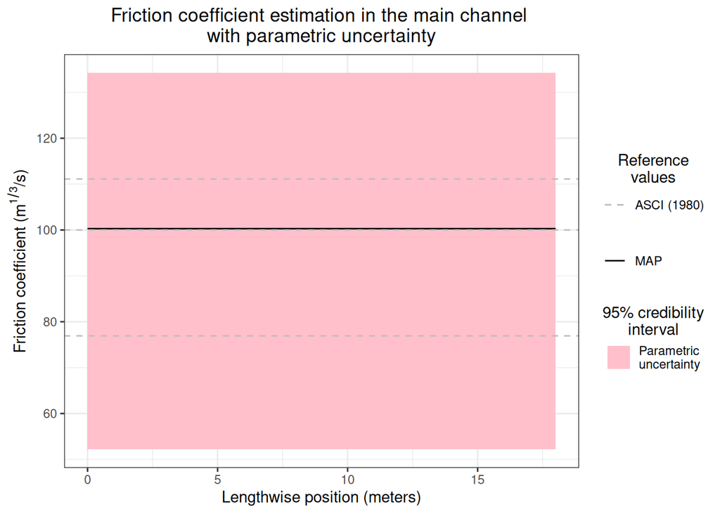

As expected, observation on the friction coefficient in the main channel lead to a good estimation for this parameter.

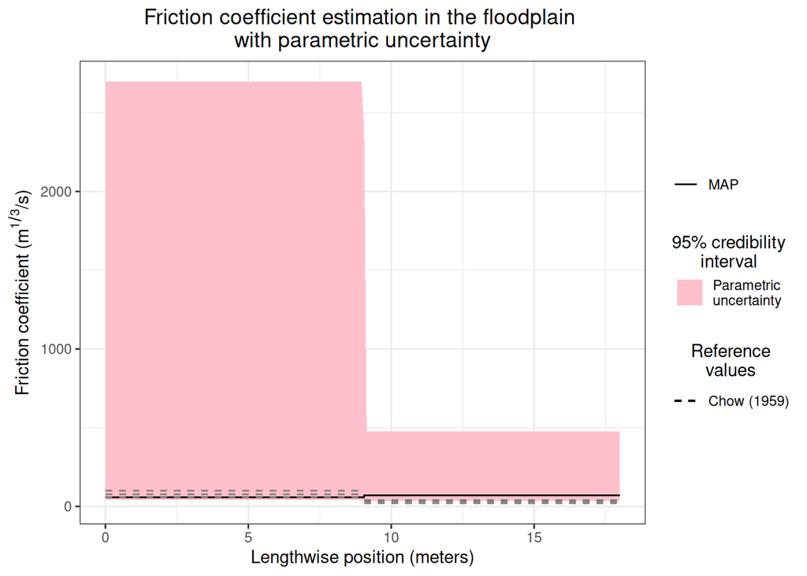

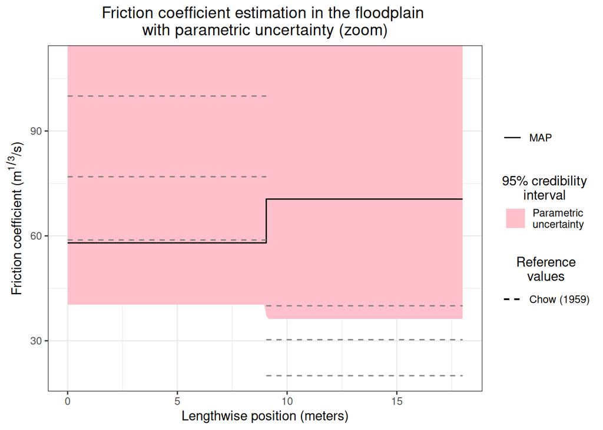

In floodplain, instabilites during the MCMC sampling do not analyse the results. That’s why a zoom have been apply to the literature values and results show that estimation of the friction coefficient upstream is sligth lower than the literature values. However, estimation is not coherent with the literature values for the second part of the floodplain (grass).

## Check of residuals

| event | reach | x | t | WSE | Discharge | Velocity | Y_Kmin | Y_Kmoy | Yu_z | Yu_Q | Yu_V | Yu_Kmin | Yu_Kmoy |
| --- | --- | --- | --- | --- | --- | --- | --- | --- | --- | --- | --- | --- | --- |
| 1 | 1 | 2.225 | 3420 | 0.1949608 | -9999 | -9999 | -9999 | -9999 | 0.0222257 | -9999 | -9999 | -9999.0 | -9999 |
| 1 | 1 | 4.310 | 3420 | 0.1880788 | -9999 | -9999 | -9999 | -9999 | 0.0222257 | -9999 | -9999 | -9999.0 | -9999 |
| 1 | 1 | 5.270 | 3420 | 0.1852095 | -9999 | -9999 | -9999 | -9999 | 0.0222257 | -9999 | -9999 | -9999.0 | -9999 |
| 1 | 1 | 6.240 | 3420 | 0.1829345 | -9999 | -9999 | 100 | -9999 | 0.0222257 | -9999 | -9999 | 0.1 | -9999 |
| 1 | 1 | 8.315 | 3420 | 0.1767361 | -9999 | -9999 | -9999 | -9999 | 0.0222257 | -9999 | -9999 | -9999.0 | -9999 |
| 1 | 1 | 9.115 | 3420 | 0.1744950 | -9999 | -9999 | -9999 | -9999 | 0.0222257 | -9999 | -9999 | -9999.0 | -9999 |
| 1 | 1 | 9.250 | 3420 | 0.1744835 | -9999 | -9999 | -9999 | -9999 | 0.0222257 | -9999 | -9999 | -9999.0 | -9999 |
| 1 | 1 | 10.250 | 3420 | 0.1737731 | -9999 | -9999 | -9999 | -9999 | 0.0222257 | -9999 | -9999 | -9999.0 | -9999 |
| 1 | 1 | 11.250 | 3420 | 0.1732561 | -9999 | -9999 | -9999 | -9999 | 0.0222257 | -9999 | -9999 | -9999.0 | -9999 |
| 1 | 1 | 12.250 | 3420 | 0.1728932 | -9999 | -9999 | -9999 | -9999 | 0.0222257 | -9999 | -9999 | -9999.0 | -9999 |
| 1 | 1 | 13.250 | 3420 | 0.1729610 | -9999 | -9999 | -9999 | -9999 | 0.0222257 | -9999 | -9999 | -9999.0 | -9999 |
| 2 | 1 | 2.225 | 3420 | 0.1902885 | -9999 | -9999 | -9999 | -9999 | 0.0222257 | -9999 | -9999 | -9999.0 | -9999 |
| 2 | 1 | 2.975 | 3420 | 0.1911852 | -9999 | -9999 | -9999 | -9999 | 0.0222257 | -9999 | -9999 | -9999.0 | -9999 |
| 2 | 1 | 3.345 | 3420 | 0.1892610 | -9999 | -9999 | -9999 | -9999 | 0.0222257 | -9999 | -9999 | -9999.0 | -9999 |
| 2 | 1 | 4.095 | 3420 | 0.1882043 | -9999 | -9999 | -9999 | -9999 | 0.0222257 | -9999 | -9999 | -9999.0 | -9999 |
| 2 | 1 | 5.060 | 3420 | 0.1864261 | -9999 | -9999 | -9999 | -9999 | 0.0222257 | -9999 | -9999 | -9999.0 | -9999 |
| 2 | 1 | 6.240 | 3420 | 0.1797323 | -9999 | -9999 | -9999 | -9999 | 0.0222257 | -9999 | -9999 | -9999.0 | -9999 |
| 2 | 1 | 6.990 | 3420 | 0.1818093 | -9999 | -9999 | -9999 | -9999 | 0.0222257 | -9999 | -9999 | -9999.0 | -9999 |
| 2 | 1 | 8.030 | 3420 | 0.1790497 | -9999 | -9999 | -9999 | -9999 | 0.0222257 | -9999 | -9999 | -9999.0 | -9999 |
| 2 | 1 | 8.795 | 3420 | 0.1743624 | -9999 | -9999 | -9999 | -9999 | 0.0222257 | -9999 | -9999 | -9999.0 | -9999 |
| 2 | 1 | 9.065 | 3420 | 0.1760431 | -9999 | -9999 | -9999 | -9999 | 0.0222257 | -9999 | -9999 | -9999.0 | -9999 |
| 2 | 1 | 9.115 | 3420 | 0.1721755 | -9999 | -9999 | -9999 | -9999 | 0.0222257 | -9999 | -9999 | -9999.0 | -9999 |
| 2 | 1 | 9.545 | 3420 | 0.1748087 | -9999 | -9999 | -9999 | -9999 | 0.0222257 | -9999 | -9999 | -9999.0 | -9999 |
| 2 | 1 | 10.030 | 3420 | 0.1738211 | -9999 | -9999 | -9999 | -9999 | 0.0222257 | -9999 | -9999 | -9999.0 | -9999 |
| 2 | 1 | 11.370 | 3420 | 0.1701349 | -9999 | -9999 | -9999 | -9999 | 0.0222257 | -9999 | -9999 | -9999.0 | -9999 |
| 2 | 1 | 12.120 | 3420 | 0.1723571 | -9999 | -9999 | -9999 | -9999 | 0.0222257 | -9999 | -9999 | -9999.0 | -9999 |
| 2 | 1 | 12.325 | 3420 | 0.1718688 | -9999 | -9999 | -9999 | -9999 | 0.0222257 | -9999 | -9999 | -9999.0 | -9999 |
| 2 | 1 | 13.290 | 3420 | 0.1715232 | -9999 | -9999 | -9999 | -9999 | 0.0222257 | -9999 | -9999 | -9999.0 | -9999 |

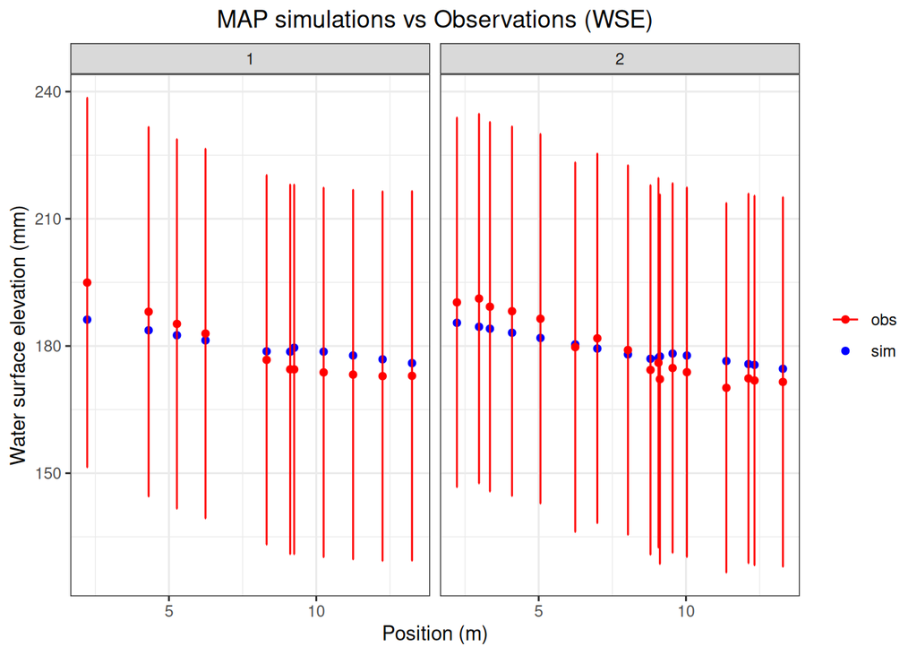

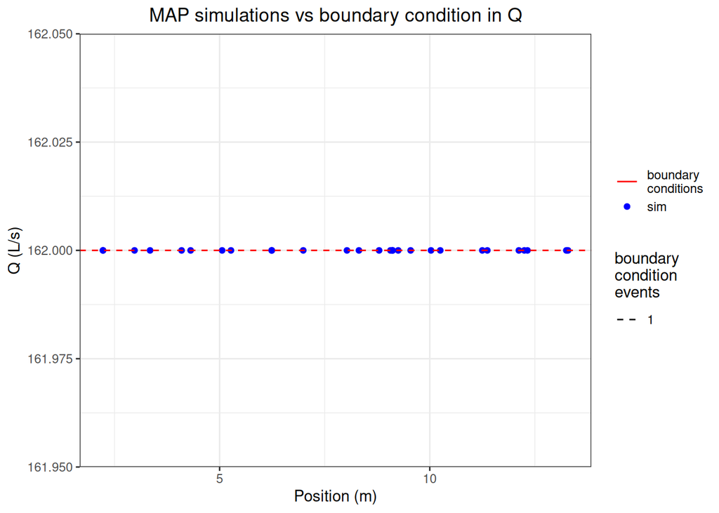

## Main conclusions:

- Estimation of the piecewise function for the friction coefficient in the floodplain and constant friction in the main channel is not working properly.
- The estimation of the friction coefficient in the floodplain is not coherent with the literature values.
- High degree of freedom would lead to instabilites during the MCMC sampling.
- As Dupuis et al. (2017) suggested, the water surface level is primarily controlled by the downstream weir levels, over the downstream roughness.

# Bibliography:

Dupuis, Victor, Sébastien Proust, Céline Berni, and André Paquier. 2017. “Compound Channel Flow with a Longitudinal Transition in Hydraulic Roughness over the Floodplains.” *Environmental Fluid Mechanics* 17 (5): 903–28. https://doi.org/10.1007/s10652-017-9525-0.